# Effects of Marine Protected Areas on California Spiny Lobster Distribution in the Santa Barbara Channel

A report prepared for ESM 206

Alicia Fennell and Rachel Rhodes

11/18/2019

# Introduction

Starting in 2012, data was collected on the abundance, size, and location of the California spiny lobster (Panulirus interruptus) in an effort to better understand the ecology of the coastal kelp forests along the Santa Barbara coast. California spiny lobsters are an important predator species that can help maintain the health of the kelp forest ecosystem by preying on herbivorous kelp-eating species like sea urchins (Guenther et al. 2012).

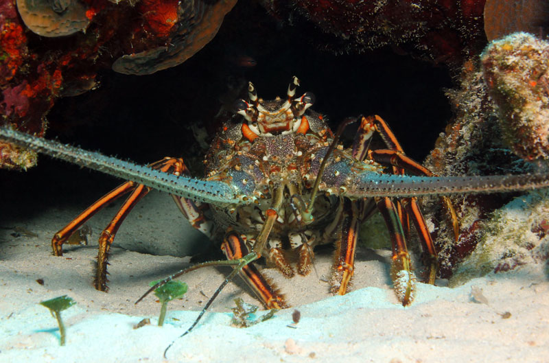

**California spiny lobster (Panulirus interruptus).** *Photo: californiadiver.com*

In January of 2012, two sites in the Santa Barbara Channel, Isla Vista and Naples, were designated as Marine Protected Areas (MPA). This designation regulates and limits human activity in a given area in an effort to conserve biodiversity and improve overall ecosystem health. In this report, findings on lobster size and abundance were compared between sites with MPA status and sites without MPA status. Furthermore, data was compared between 2012 and 2018 to explore trends in lobster distribution over time. This data is relevant in assessing the effectiveness of MPA designation and how it impacts lobster abundance and size.

# Data and Methods

The Santa Barbara Coastal Long Term Ecological Research program at UC Santa Barbara collected data for the abundance, size, and location of California spiny lobsters along the coast of the Santa Barbara Channel from 2012-2018. Spiny lobster abundance and size data was collected during annual dives before the start of the fishing season in late summer at five sites. Divers recorded the number and size of spiny lobsters at four 60m x 5 m (300 m<sup>2</sup> total) transects at each site. Two of the sites, Naples and Isla Vista, are Marine Protected Areas that were established in January 2012. Lobster abundance and size distribution for MPA sites and non-MPA sites were compared using two-sided, two-sample t-tests with a 95% confidence interval and Cohen’s *d*. All analyses and figures were prepared using R software version 3.6.1.

# Results

#### 1. Effects of Marine Protected Area designation on spiny lobster abundance

The annual abundance of California spiny lobster was compared between 2012 and 2018 at five different sites, including two sites within recently designated Marine Protected Areas (Figure 1). Overall, the total lobster abundance at MPA sites increased more than non-MPA sites. Total lobster counts within protected sites increased dramatically from 32 to 1,244 between the years 2012 and 2018. Total lobster counts in non portected sites also increased, but the change was less dramatic (total lobster counts increased from 199 to 561). Of all five sites, abundance of lobsters at Isla Vista (an MPA site) increased the most by 2018.

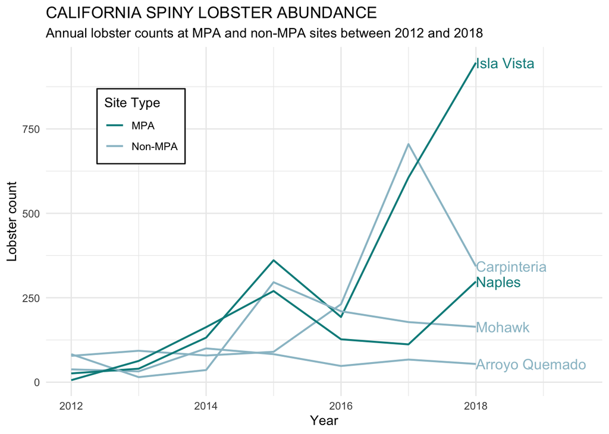

*Figure 1.* *California spiny lobster abundance (counts) at transects within Marine Protected Areas (dark teal) and at transects not within Marine Protected Areas (light blue) between 2012 and 2018. Total lobster counts in 2012: MPA(n) = 32, non-MPA(n) = 199. Total lobster counts in 2018: MPA(n) = 1244, non-MPA(n) = 561.*

#### 2. Lobster size distribution shifts between 2012 and 2018

In addition to changes in lobster abundance, size differences in lobsters were observed across the different sites and years. Figure 2 explores size distribution shifts between 2012 and 2018 across the five sites.

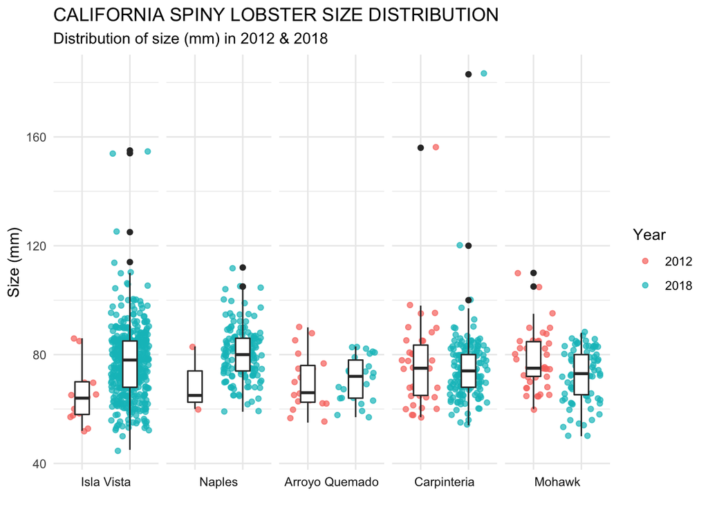

*Figure 2.* *Size distribution of California spiny lobsters at each site in 2012 compared to 2018. In the box plots, the solid line in the middle represents the median of that sample, while the box itself includes the middle 50% of the data. The whiskers extend to include the remaining 25% of observations on either side of the box, and the solid points indicate outliers. The jitter points behind the boxes are included to show the actual distribution of observed data points. The MPA sites are the first two sites on the graph (Isla Vista and Naples).*

The median size of lobsters recorded in 2012 and 2018 differed more in MPA sites than in non-MPA sites. The median size in MPA sites in 2012 was 64.5 mm, while the median in 2018 was 78 mm. In non-MPA sites, the difference was smaller; the median went from 75 mm in 2012 to 73 mm in 2018. Lobster abudnace in all sites increased, most notably at the Isla Vista site, similar to the trends in abundance in Figure 1. A small number of outliers in size were observed at all sites except Arroyo Quemado.

#### 3. Mean lobster sizes between site types (MPA and non-MPA) and years (2012 and 2018)

Summary statistics were calculated for lobster size in Marine Protected Area sites versus non-Marine Protected Area sites in 2012 and 2018. Mean lobster size (mm) was compared and analyzed using two-sided, two-sample t-tests for four groupings: MPA and non-MPA sites in 2012, MPA and non-MPA sites in 2018, MPA sites in 2012 and 2018, and non-MPA sites in 2012 and 2018.

*Table 1.* *Lobster size distribution in 2012 and 2018 in MPA and non-MPA sites. Mean size, standard deviation, and sample size are compared between years and protection status (site type).*

| Summary of Lobster Size Distribution Site Type | Summary of Lobster Size Distribution Year | Summary of Lobster Size Distribution Mean Size (mm) | Summary of Lobster Size Distribution Standard Deviation | Summary of Lobster Size Distribution Sample Size (n) |
| --- | --- | --- | --- | --- |
| MPA | 2012 | 67.38 | 12.15 | 32 |
| MPA | 2018 | 77.57 | 11.70 | 1244 |
| Non-MPA | 2012 | 74.92 | 12.41 | 199 |
| Non-MPA | 2018 | 73.62 | 10.09 | 561 |

In both 2012 and 2018, the mean lobster size differed depending on the site type, Marine Protected Areas versus non-Marine Protected Areas. In 2012, the mean lobster size (mm) in MPA sites (67.38 $\pm$ 12.15, n = 32) was smaller than the mean size in non-MPA sites (74.92 $\pm$ 12.41, n = 199). This difference in means of 7.54 mm was determined to be significant using a two-sided, two-sample t-test (t(42.09) = -3.25, *p* = 0.002) with a medium effect size (Cohen’s *d* = -0.61).

In 2018, mean lobster size again differed based on MPA status. This year, mean lobster size in MPA sites (77.57 $\pm$ 11.7, n = 1244) was greater than the mean lobster size in non-MPA sites (73.62 $\pm$ 10.09, n = 561). This difference (3.95 mm) was again statistically significant based on a two-sided, two-sample t-test (t(1239.51) = 7.31, *p* < .001) with a medium-small effect size (Cohen’s *d* = 0.35).

Comparing lobster size between 2012 and 2018, there was a dramatic shift in mean lobster size (mm) at MPA sites (67.38 and 77.57). This increase in mean size by 10.19 mm was significantly different (t(32.5) = -4.69, *p* < .001) and effect size was large (Cohen’s *d* = -0.87).

In contrast, mean lobster size (mm) in non-MPA sites remained relatively constant between 2012 and 2018. The difference in mean lobster size was only 1.3 with a small effect size (Cohen’s *d* = 0.12). The slight decrease (74.92 to 73.62) was not significantly different using a two-sample t-test (t(296.01) = 1.33, *p* = 0.183).

## Summary

- Abundance of lobsters in both MPA and non-MPA sites increased between 2012 and 2018, with the most dramatic increase observed at Marine Protected Sites, particularly at the Isla Vista site (Figure 1).
- Mean lobster size in MPA sites differed significantly between 2012 and 2018. The increase in mean lobster size at MPA sites during this period was 10.19 mm, while the mean lobster size at non-MPA decreased by 1.3 mm and did not differ significantly (Table 1).
- From 2012 to 2018, both lobster size and abundance increased more in Marine Protected Areas than in sites without this designation. Based on these findings, it is possible that Marine Protected Area status has an effect on lobster size and abundance.

## References

**Guenther, Carla M et al.** *Trophic cascades induced by lobster fishing are not ubiquitous in southern California kelp forests.* PloS one vol. 7,11 (2012): e49396. [doi:10.1371/journal.pone.0049396](https://www.ncbi.nlm.nih.gov/pmc/articles/PMC3510206/)

**Reed D. 2019.** *SBC LTER: Reef: Abundance, size and fishing effort for California Spiny Lobster (Panulirus interruptus), ongoing since 2012.* Environmental Data Initiative. https://doi.org/10.6073/pasta/a593a675d644fdefb736750b291579a0. Dataset accessed 11/15/2019.